# Iris Data k-Nearest-Neighbour

A contrast to model-based learning is K-Nearest neighbour. This is also called instance-based learning because it doesn’t even leran a single model. The training process involves memorizing all the training data. To predict a new data point, we found the closest K (a tunable parameter) neighbours from the training set and let them vote for the final prediciton.

To determine the “nearest neighbours” a distance function needs to be defined (e.g. a Euclidian distance function is a common one for the numeric input variables). The voting can also be weighted among the K-neighbors baesd on their distance from the new data point.

The strenght of k-nearest neighbours is its simplicity. No model needs to be trained. Incremental learning is automatic when more data arrives (and old data can be deleted as well). The weakness of kNN, however, is that it doesn’t handle high numbers of dimensions well.

Data IRIS:

```r
iris
```

| Sepal.Length | Sepal.Width | Petal.Length | Petal.Width | Species |
| --- | --- | --- | --- | --- |
| 5.1 | 3.5 | 1.4 | 0.2 | setosa |
| 4.9 | 3.0 | 1.4 | 0.2 | setosa |
| 4.7 | 3.2 | 1.3 | 0.2 | setosa |
| 4.6 | 3.1 | 1.5 | 0.2 | setosa |
| 5.0 | 3.6 | 1.4 | 0.2 | setosa |
| 5.4 | 3.9 | 1.7 | 0.4 | setosa |
| 4.6 | 3.4 | 1.4 | 0.3 | setosa |
| 5.0 | 3.4 | 1.5 | 0.2 | setosa |
| 4.4 | 2.9 | 1.4 | 0.2 | setosa |
| 4.9 | 3.1 | 1.5 | 0.1 | setosa |

[output cut: 140 more lines]

```r
summary(iris)
```

```
  Sepal.Length    Sepal.Width     Petal.Length    Petal.Width          Species
 Min.   :4.300   Min.   :2.000   Min.   :1.000   Min.   :0.100   setosa    :50
 1st Qu.:5.100   1st Qu.:2.800   1st Qu.:1.600   1st Qu.:0.300   versicolor:50
 Median :5.800   Median :3.000   Median :4.350   Median :1.300   virginica :50
 Mean   :5.843   Mean   :3.057   Mean   :3.758   Mean   :1.199
 3rd Qu.:6.400   3rd Qu.:3.300   3rd Qu.:5.100   3rd Qu.:1.800
 Max.   :7.900   Max.   :4.400   Max.   :6.900   Max.   :2.500
```

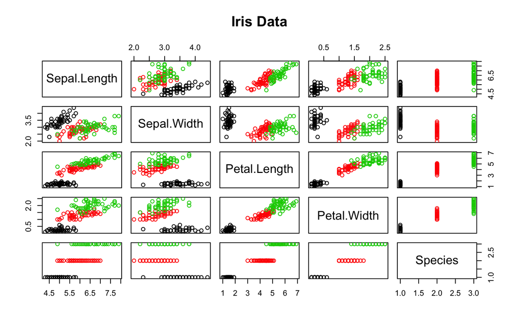

```r
pairs(main="Iris Data", iris, col=iris$Species)
```

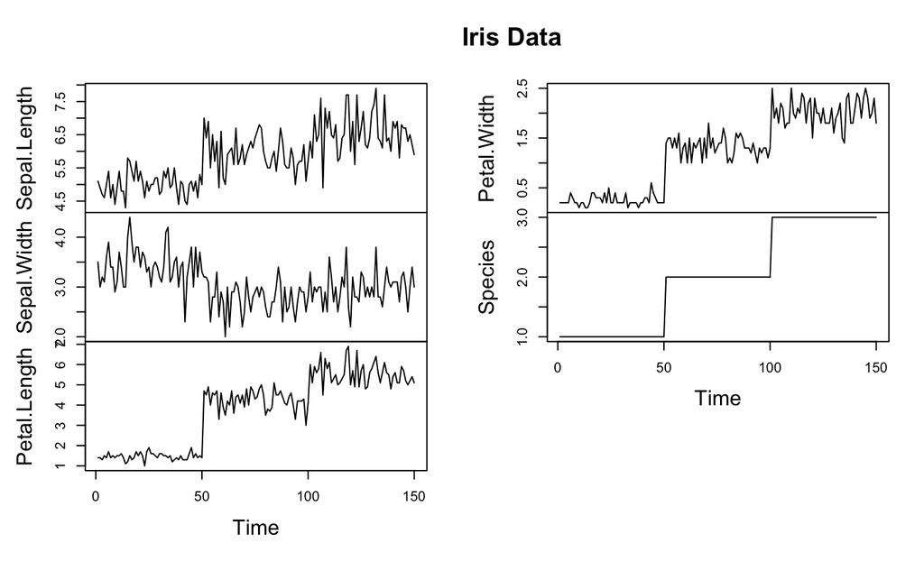

```r
plot.ts(main="Iris Data", iris)
```

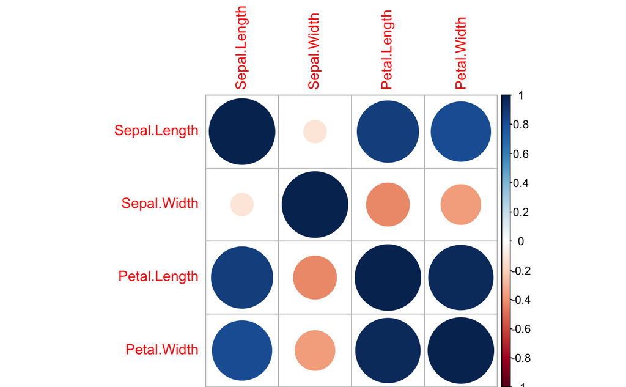

```r
d <- data.frame(Sepal.Length = iris$Sepal.Length, Sepal.Width = iris$Sepal.Width, Petal.Length = iris$Petal.Length, Petal.Width = iris$Petal.Width)
m <- cor(d)
library('corrplot')
corrplot(m, method="circle")
```

Create build index:

```r
testidx <- which(1:length(iris[,1])%%3==0)
```

separate training data from test:

```r
iristrain <- iris[-testidx,]
iristest <- iris[testidx,]
train_input <- as.matrix(iristrain[,-5])
train_output <- as.vector(iristrain[,5])
test_input <- as.matrix(iristest[,-5])
```

```r
library(class)
predict <- knn(train_input, test_input, train_output, k=10)
table(predict, iristest$Species)
```

```
predict      setosa versicolor virginica
  setosa         16          0         0
  versicolor      0         15         1
  virginica       0          2        16
```

Next Example

```r
train <- rbind(iris3[1:25,,1], iris3[1:25,,2], iris3[1:25,,3])
test <- rbind(iris3[26:50,,1], iris3[26:50,,2], iris3[26:50,,3])
cl <- factor(c(rep("s",25), rep("c",25), rep("v",25)))
require(class)
iris_pred <- knn(train, test, cl, k = 3, prob=TRUE)
iris_pred
```

```
 [1] s s s s s s s s s s s s s s s s s s s s s s s s s c c v c c c c c v c c c c c c c c c c c c c c c c v c c v v v v v v v v v v c v v v v v v v v v v v
attr(,"prob")
 [1] 1.0000000 1.0000000 1.0000000 1.0000000 1.0000000 1.0000000 1.0000000 1.0000000 1.0000000 1.0000000 1.0000000 1.0000000 1.0000000 1.0000000 1.0000000 1.0000000 1.0000000
[18] 1.0000000 1.0000000 1.0000000 1.0000000 1.0000000 1.0000000 1.0000000 1.0000000 1.0000000 1.0000000 0.6666667 1.0000000 1.0000000 1.0000000 1.0000000 1.0000000 0.6666667
[35] 1.0000000 1.0000000 1.0000000 1.0000000 1.0000000 1.0000000 1.0000000 1.0000000 1.0000000 1.0000000 1.0000000 1.0000000 1.0000000 1.0000000 1.0000000 1.0000000 1.0000000
[52] 0.6666667 0.7500000 1.0000000 1.0000000 1.0000000 1.0000000 1.0000000 0.5000000 1.0000000 1.0000000 1.0000000 1.0000000 0.6666667 1.0000000 1.0000000 1.0000000 1.0000000
[69] 1.0000000 1.0000000 1.0000000 0.6666667 1.0000000 1.0000000 0.6666667
Levels: c s v
```